# Homework 2

Ken Lau

I like using ‘=’ instead of ‘<-’. There are debates over this, so it’s just my own preference.

## Reading in Data

### Read in data with only file parameter

```r
gdURL <- "http://tiny.cc/gapminder"
gDat <- read.delim(file = gdURL)
str(gDat)
```

```
## 'data.frame':    1704 obs. of  6 variables:
##  $ country  : Factor w/ 142 levels "Afghanistan",..: 1 1 1 1 1 1 1 1 1 1 ...
##  $ year     : int  1952 1957 1962 1967 1972 1977 1982 1987 1992 1997 ...
##  $ pop      : num  8425333 9240934 10267083 11537966 13079460 ...
##  $ continent: Factor w/ 5 levels "Africa","Americas",..: 3 3 3 3 3 3 3 3 3 3 ...
##  $ lifeExp  : num  28.8 30.3 32 34 36.1 ...
##  $ gdpPercap: num  779 821 853 836 740 ...
```

```r
gDat = read.table(file = gdURL, sep=" ")
str(gDat)
```

```
## 'data.frame':    2137 obs. of  1 variable:
##  $ V1: Factor w/ 1729 levels "Afghanistan\t1952\t8425333\tAsia\t28.801\t779.4453145",..: 334 1 2 3 4 5 6 7 8 9 ...
```

I included sep=" " above to allow read.table to import the data successfully. Clearly read.table did not read in the table correctly since it only has one column. read.table incorrectly combined each row into a single string. Moreover, it has 2137 rows rather than 1704 rows from read.delim.

The reason mostly stems from the ‘header=F’ and ‘sep=“”’ or ‘sep=’" “’ which are the default parameter settings for read.table.

### Correctly read in data with read.table

```r
gdURL <- "http://tiny.cc/gapminder"
gDat = read.table(file = gdURL, header=T, sep="\t", quote="\"")
str(gDat)
```

```
## 'data.frame':    1704 obs. of  6 variables:
##  $ country  : Factor w/ 142 levels "Afghanistan",..: 1 1 1 1 1 1 1 1 1 1 ...
##  $ year     : int  1952 1957 1962 1967 1972 1977 1982 1987 1992 1997 ...
##  $ pop      : num  8425333 9240934 10267083 11537966 13079460 ...
##  $ continent: Factor w/ 5 levels "Africa","Americas",..: 3 3 3 3 3 3 3 3 3 3 ...
##  $ lifeExp  : num  28.8 30.3 32 34 36.1 ...
##  $ gdpPercap: num  779 821 853 836 740 ...
```

There were three parameters we needed to set to achieve the same results to read.delim:

1. header=T sets the first row to be names of columns for data frame
2. sep=“\t” sets the delimeter of the file to be tab delimited
3. quote=“\”" sets the quoting characters to be ASCII quotation mark "

### Smell test the data

#### Is it a data.frame, a matrix, a vector, a list?

Clearly, it’s a data.frame

```r
class(gDat)
```

```
## [1] "data.frame"
```

#### Whats its mode, class?

```r
# The mode is:
mode(gDat)
```

```
## [1] "list"
```

```r
# The class is:
class(gDat)
```

```
## [1] "data.frame"
```

#### How many variables?

```r
names(gDat)
```

```
## [1] "country"   "year"      "pop"       "continent" "lifeExp"   "gdpPercap"
```

```r
# number of variables:
length(names(gDat))
```

```
## [1] 6
```

#### How many rows/observations?

There are 1704 rows.

#### Can you get these facts about “extent” or “size” in more than one way? Can you imagine different functions being useful in different contexts?

str() essentially gives you almost all the answers to the questions above. Additionally, I used class(), names() to determine the class and number of columns. dim() gives the number of rows and columns.

It is useful to know different ways to extract information. For example, str() gives you and overview of the dataset. However, it’s harder to explictly extract the info to use. However, if I need to use the size of a data frame say to create a new matrix of the same size. It can be done simply.

```r
zeroMatrix = matrix(0, nrow=dim(gDat)[1], ncol=dim(gDat)[2])
head(zeroMatrix)
```

```
##      [,1] [,2] [,3] [,4] [,5] [,6]
## [1,]    0    0    0    0    0    0
## [2,]    0    0    0    0    0    0
## [3,]    0    0    0    0    0    0
## [4,]    0    0    0    0    0    0
## [5,]    0    0    0    0    0    0
## [6,]    0    0    0    0    0    0
```

#### What flavor is each the variable?

From structure of the data. We have country is a factor, year is int, pop is numeric, continet is a factor, lifeExp is a numeric, and gdpPercp is a numeric.

### Explore individual variables

```r
# average value of life expectancy
mean(gDat$lifeExp)
```

```
## [1] 59.47
```

```r
# summary statistics of life expectancy
summary(gDat$lifeExp)
```

```
##    Min. 1st Qu.  Median    Mean 3rd Qu.    Max.
##    23.6    48.2    60.7    59.5    70.8    82.6
```

```r
# calculate the mean life expectancy for each continent
tapply(gDat$lifeExp, gDat$continent, FUN=mean)
```

```
##   Africa Americas     Asia   Europe  Oceania
##    48.87    64.66    60.06    71.90    74.33
```

```
## stat_bin: binwidth defaulted to range/30. Use 'binwidth = x' to adjust this.
```

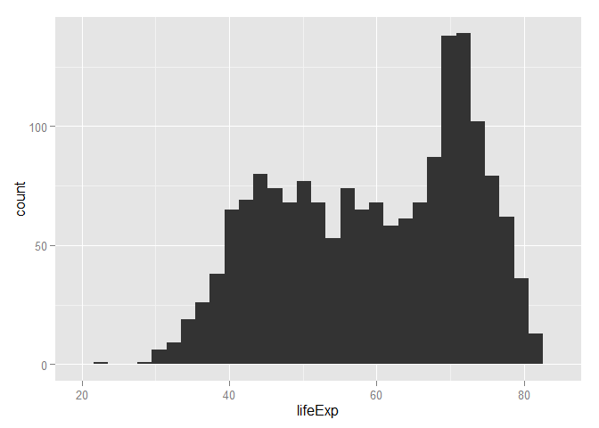

```r
# histogram of life expectancy
ggplot(data=gDat, aes(x=lifeExp)) + geom_histogram()
```

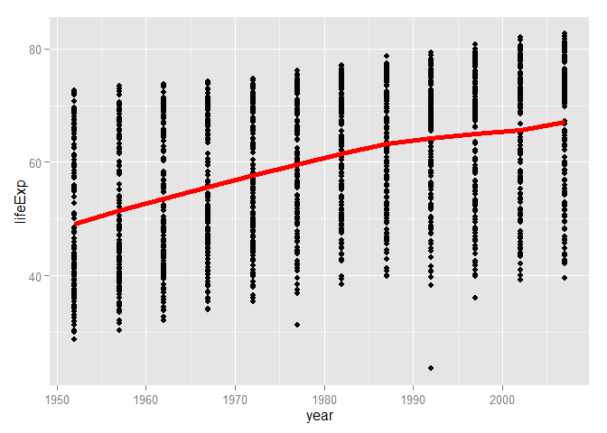

```r
# create initial scatter plot of year vs life expectancy
gg = qplot(year, lifeExp, data=gDat)
# create a helper function for fun to be used for aggregation
# in ggplot
stat_sum_single = function(fun, geom="point", colour="red",
                    size=2){
  stat_summary(fun.y=fun, colour=colour, geom=geom, size=size)
}
# draw the trend line in red
gg + stat_sum_single(fun=mean, geom="line")
```

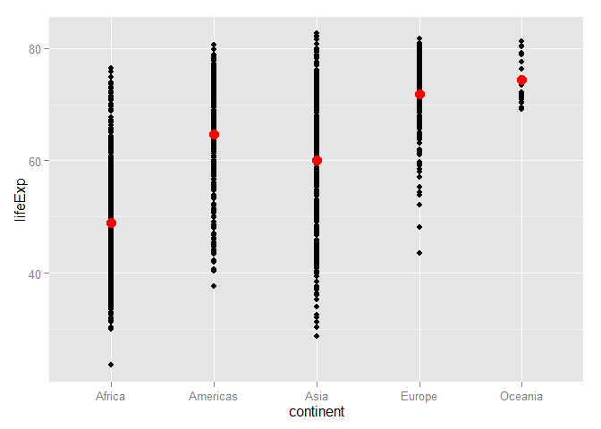

```r
# create initial scatter plot of continent vs life expectancy
gg = qplot(continent, lifeExp, data=gDat)
# plot the means for each continent in red
gg + stat_sum_single(fun=mean, size=4)
```

We see that the Africa has the lowest life expectancy. Europe and Oceania have the greatest life expectancy. America and Asia sit somewhere in between. Asia and Africa appears to have the greatest range. Asia also have the greatest life expectancy in one of its countries.

### IPython Notebook

Please see homework2IPython.html for my python analysis of the gapminder dataset. This is done using an IPython Notebook.

### Report of Process

Overall nothing too dificult in R. Most of the work is in getting the R Markdown syntax. It took a lot longer to complete the IPython Notebook as it is my first time. However, it is an incredibly rewarding experience.